# Ecological status of surface water

[NO_WECO_001] (fraction of rivers with good status)  
[NO_WECO_002] (fraction of lakes with good status)  
[NO_WECO_003] (fraction of coast with good status)  
[NO_WECO_004] (fraction of rivers with good status or potential)  
[NO_WECO_005] (fraction of lakes with good status or potential)  
[NO_WECO_006] (fraction of coast with good status or potential)  
[NO_WECO_007] (weighted fraction of rivers with good status)  
[NO_WECO_008] (weighted fraction of lakes with good status)  
[NO_WECO_009] (weighted fraction of coast with good status)  
[NO_WECO_010] (average status of rivers)  
[NO_WECO_011] (average status of lakes)  
[NO_WECO_012] (average status of coast)

Author

Affiliation

Hanno Sandvik

Norwegian Institute for Nature Research

Published

November 6, 2025

> **Recommended citation**: Sandvik, H. 2025. Ecological status of surface water (ID: NO_WECO_001; NO_WECO_002; NO_WECO_003; NO_WECO_004; NO_WECO_005; NO_WECO_006; NO_WECO_007; NO_WECO_008; NO_WECO_009; NO_WECO_010; NO_WECO_011; NO_WECO_012) v. 000.900. ecRxiv: https://github.com/NINAnor/ecRxiv/tree/main/indicators/NO_WECO_001-012

**Metadata**

Table 1: Indicator metadata

| Variable | Value |
| --- | --- |
| Indicator ID | NO_WECO_001; NO_WECO_002; NO_WECO_003; NO_WECO_004; NO_WECO_005; NO_WECO_006; NO_WECO_007; NO_WECO_008; NO_WECO_009; NO_WECO_010; NO_WECO_011; NO_WECO_012 |
| Indicator Name | Ecological status of surface water |
| Country | Norway |
| Continent | Europe |
| Ecosystem Condition Typology Class | Other |
| Realm | Freshwater (F); Freshwater (F); Marine (F); Freshwater (F); Freshwater (F); Marine (F); Freshwater (F); Freshwater (F); Marine (F); Freshwater (F); Freshwater (F); Marine (F) |
| Biome | F1 Rivers and streams biome; F2 Lakes biome; M1 Marine shelf biome; F1 Rivers and streams biome; F2 Lakes biome; M1 Marine shelf biome; F1 Rivers and streams biome; F2 Lakes biome; M1 Marine shelf bio… |
| Ecosystem | F1.3 Freeze-thaw streams; F2.4 Freeze-thaw freshwater lakes; Several ecosystems; F1.3 Freeze-thaw streams; F2.4 Freeze-thaw freshwater lakes; Several ecosystems; F1.3 Freeze-thaw streams; F2.4 Freeze-… |
| Year added | 2025 |
| Last update | 2025 |
| Version | 000.900 |
| Version comment | First complete version |
| Normalised | TRUE |
| Spatial aggregation pathway | Truncate - Scale - Transform - Aggregate |

**Log**

- 12 Aug 2025 - Version 000.900 started: first complete version
- 29 Oct 2025 - Code review by ALK
- 06 Nov 2025 - Version 000.900 revised and ready for publication

## 1. Summary

1. **Background and rationale**: The *Water Framework Directive* (hereafter **WFD**) has established a system to describe the ecological status of rivers (+ canals), lakes (+ reservoirs) and coastal waters (collectively referred to as *surface waters*). Within this framework, ecological status is assessed using a set of *parameters* (indicators) that express the condition of *biological quality elements* (aquatic flora, fish fauna, invertebrate fauna, phytoplankton) and *supporting elements* (hydromorphology, chemical and physico-chemical conditions) relative to anthropogenic *pressures* (such as acidification, eutrophication, pollution, regulation). Parameters are measured in (or transformed to) a common scale from 0 to 1, called *normalized Ecological Quality Ratio* (nEQR; equivalent to scaled indicators in SEEA EA). The overall status of a water body is determined by the quality element with the lowest nEQR (i.e., parameters are combined using the one-out–all-out principle rather than averaging).  
   Whereas several WFD parameters are applicable and valid as ecosystem condition indicators according to SEEA EA (see section 3.3), Eurostat has also recommended the use of the “percentage of rivers and canals / lakes and reservoirs with *good ecological status*” (i.e., nEQR > 0.6) as an ecosystem condition indicator. However, such an indicator is incompatible with the SEEA EA guidelines and has undesirable mathematical properties: (**1**) many different parameters are combined in one *composite* index; (**2**) in doing so, the one-out–all-out (*1OAO*) principle is used; (**3**) values are not weighted by the *area* of the ecosystem assets; (**4**) the indicator uses *proportions* and cut-off values (0.6) rather than actual values (see section 3.6 for more detail).  
   For these reasons, we discourage the use of this indicator. As it is recommended by Eurostat, however, we here document how it can be estimated, and how *some* (but emphatically not all) of its incompatibilities with SEEA EA can be removed by modifying its definition. The definitions suggested are (**A**) unweighted proportion of water bodies with at least good ecological status; (**B**) unweighted proportion of water bodies with at least good ecological status *or good ecological potential*; (**C**) *size-weighted* proportion of water bodies with at least good ecological status; (**D**) size-weighted *average* of ecological status or ecological potential (see chapter 9 for more detail). With four indicator definitions and three ecosystem types (or “surface water categories” sensu WFD), a total of twelve indicators are described (Table 2).

Table 2: Overview of indicators.

| Indicator ID | Ecosystem | Definition | Problem 1: composite | Problem 2: 1OAO | Problem 3: area | Problem 4: proportion |
| --- | --- | --- | --- | --- | --- | --- |
| NO_WECO_001 | River | A | X | X | X | X |
| NO_WECO_002 | Lake | A | X | X | X | X |
| NO_WECO_003 | Coastal water | A | X | X | X | X |
| NO_WECO_004 | River | B | X | X | X | X |
| NO_WECO_005 | Lake | B | X | X | X | X |
| NO_WECO_006 | Coastal water | B | X | X | X | X |
| NO_WECO_007 | River | C | X | X | ✓ | X |
| NO_WECO_008 | Lake | C | X | X | ✓ | X |
| NO_WECO_009 | Coastal water | C | X | X | ✓ | X |
| NO_WECO_010 | River | D | X | X | ✓ | ✓ |
| NO_WECO_011 | Lake | D | X | X | ✓ | ✓ |
| NO_WECO_012 | Coastal water | D | X | X | ✓ | ✓ |

2. **Methods**: In Norway, the WFD is implemented through *Vannforskriften*, and relevant parameters are described in national guidelines (DGVF 2025). The status assessments of Norwegian water bodies are available from the *Vann-nett* database.
3. **Interpretation**: For indicators NO_WECO_001–009, a value of 1 signifies that all water bodies deviate only slightly, if at all, from undisturbed conditions; values decreasing toward zero reflect lower percentages of water bodies meeting this criterion. For indicators NO_WECO_010–012, a value of 1 signifies a condition where there is little or no human impact on the water body; values decreasing toward zero reflect negative ecological change.
4. **Results and development needs**: The indicator is ready for use in principle, but is tagged as “deprecated” because its use cannot be recommended for reasons that cannot be overcome by further development.

## 2. About the underlying data

Information on the ecological status of all Norwegian water bodies is collected in a common database called *Vann-nett*, which is maintained by the [Norwegian Environment Agency](https://www.miljodirektoratet.no/).

### 2.1 Spatial and temporal resolution and extent

The **spatial** resolution of WFD data is on the level of *water bodies*. The WFD defines a water body (specifically a “body of surface water”) as “a discrete and significant element of surface water such as a lake, a reservoir, a stream, river or canal, [or] part of a stream, river or canal” (WFD, Article 2, paragraph 10; cf. *Vannforskriften* § 3, letter a; for implementation, see DGVF 2018, ch. 2).

There is no specific **temporal** resolution, as measurements of WFD indicators are reported sporadically. The estimation of overall ecological status is based on measurements from the most recent six years within the ten-year interval up to and including the current year.

### 2.2 Sampling design

WFD indicators are mainly measured opportunistically, e.g. when and where some authority has a need to check whether a water body fulfils the management objective of the WFD. However, a subset of the measurements is taken systematically, e.g. repeated measurements in a sample of water bodies that have been selected following certain criteria.

### 2.3 Original units

The ecological status of water bodies may be reported in terms of continuous nEQR values (normalized Ecological Quality Ratios) between 0 and 1, or in terms of five discrete categories (see section on reference levels below).

### 2.4 Instructions for citing, using and accessing data

The data used are publicly available but not machine-readable. They need to be downloaded manually from a database called *Vann-nett* via the link https://vann-nett.no/waterbodies/report. See *Vann-nett* for how to cite the dataset.

## 3. Indicator properties

Ecological status of surface water has the ID **131** in the metadata table for ecological condition variables for use in Norway (Czúcz et al. 2023).

Eurostat has listed the percentage of water bodies with good ecological status as a *voluntary condition variable* for reporting in connection with the EU Regulation 2024/3024 (EU 2024, Annex IX; cf. Czúcz el at. 2025).

### 3.1 Ecosystem Condition Typology Class (ECT)

Being a composite index across a large number of individual WFD parameters, the “ecological status of surface water” potentially covers all ECT classes. The best represented class is probably **A2** (chemical state), but WFD parameters belonging to A1, B1, B2, B3 and possibly C1 are also included when estimating index values.

#### 3.1.1 Other condition typologies

Being a composite index across a large number of individual WFD parameters, the “ecological status of surface water” potentially covers all ecological characteristics (*økologiske egenskaper*) sensu Nybø & Evju (2017, p. 35) and all biological quality elements sensu WFD (Annex V).

### 3.2 Ecosystem condition characteristic

Not applicable.

### 3.3 Collinearities with other indicators

Being a composite index calculated from a large number of individual WFD parameters, the “ecological status of surface water” necessarily has collinearities with at least some – and potentially all – of these parameters. (As the one-out–all-out principle is used, it may be the case that a certain parameter always indicates a better ecological status than all others, in which case there would be no collinearity between this specific parameter and the composite index.)

The WFD parameters that have been implemented as ecosystem condition indicators in Norway as of 2025 are:

Table 3: Other freshwater indicators.

| Parameter Name | Indicator ID | Ecosystem | ECT | Quality element | Pressure |
| --- | --- | --- | --- | --- | --- |
| RAMI | NO_WAMI_001 | River | A2 | invertebrate fauna | acidification |
| ASPT | NO_WSPT_001 | River | A2 | invertebrate fauna | eutrophication |
| AIP | NO_WAIP_001 | River | A2 | aquatic flora | acidification |
| PIT | NO_WPIT_001 | River | A2 | aquatic flora | eutrophication |
| Chlorophyll *a* | NO_WCHL_001 | Lake | B2 | phytoplankton | eutrophication |
| Phytoplankton biomass (PPB) | NO_WPPB_001 | Lake | B2 | phytoplankton | eutrophication |
| PTI | NO_WPTI_001 | Lake | A2 | phytoplankton | eutrophication |
| Acid-neutralising capacity (ANC) | [NO_WANC_001](https://github.com/NINAnor/ecRxiv/tree/main/indicators/NO_WANC_001_002) | River | A2 | chemical | acidification |
| ANC | [NO_WANC_002](https://github.com/NINAnor/ecRxiv/tree/main/indicators/NO_WANC_001_002) | Lake | A2 | chemical | acidification |
| Labile aluminium | [NO_WLAL_001](https://github.com/NINAnor/ecRxiv/tree/main/indicators/NO_WLAL_001_002) | River | A2 | chemical | acidification |
| Labile aluminium | [NO_WLAL_002](https://github.com/NINAnor/ecRxiv/tree/main/indicators/NO_WLAL_001_002) | Lake | A2 | chemical | acidification |
| pH | [NO_WPHX_001](https://github.com/NINAnor/ecRxiv/tree/main/indicators/NO_WPHX_001_002) | River | A2 | chemical | acidification |
| pH | [NO_WPHX_002](https://github.com/NINAnor/ecRxiv/tree/main/indicators/NO_WPHX_001_002) | Lake | A2 | chemical | acidification |
| (Total nitrogen) | [NO_WTNX_001](https://github.com/NINAnor/ecRxiv/tree/main/indicators/NO_WTNX_001_002) | River | A2 | chemical | eutrophication |
| (Total nitrogen) | [NO_WTNX_002](https://github.com/NINAnor/ecRxiv/tree/main/indicators/NO_WTNX_001_002) | Lake | A2 | chemical | eutrophication |
| Total phosphorus | [NO_WTPX_001](https://github.com/NINAnor/ecRxiv/tree/main/indicators/NO_WTPX_001_002) | River | A2 | chemical | eutrophication |
| Total phosphorus | [NO_WTPX_002](https://github.com/NINAnor/ecRxiv/tree/main/indicators/NO_WTPX_001_002) | Lake | A2 | chemical | eutrophication |
| Water level regulation | NO_WLEV_001 | Lake | A1 | hydromorphology | regulation |

In contrast to “ecological status of surface water”, the above indicators (except total nitrogen, which cannot be scaled and is deprecated) are fully compatible with SEEA EA. SEEA EA (5.79–90) also suggests defining aggregated *indices* that are calculated from sets of similar indicators, e.g. as a weighted average of all ecosystem condition indicators for lakes. This procedure is thus preferable to using “ecological status of surface water” as an indicator in its own right. To illustrate how this might be carried out in line with “WFD thinking” (as described in DGVF 2025), one can assign the same weight to each pressure, and downweight chemical indicators to get the same cumulative weight as one biological indicator.

For rivers, such an index might thus be calculated as

$$(\text{ASPT} / 3 + \text{PIT} / 3 + \text{TP} / 3) / 2 + (\text{RAMI} / 3 + \text{API} / 3 + \text{ANC} / 9 + \text{LAL} / 9 + \text{PH} / 9) / 2$$

Analogously, a lake condition index might be calculated as

$$(\text{PTI} / 3 + \text{CHL} / 6 + \text{PPB} / 6 + \text{TP} / 3) / 3 + (\text{ANC} / 3 + \text{LAL} / 3 + \text{PH} / 3) / 3 + \text{WLEV} / 3$$

These index definitions only include WFD indicators. Other freshwater indicators (such as salmon stock quality, NO_SALM_001) can – and should – be included following the same approach.

### 3.4 Impact factors

Being a composite index across a large number of individual WFD parameters, the “ecological status of surface water” potentially covers all relevant anthropogenic impacts (pressures), including acidification, eutrophication, pollution, and possibly regulation.

### 3.5 Spatial aggregation

According to the WFD and DGVF (2025), measurements of WFD variables are transformed into so-called nEQR values (“normalised Ecological Quality Ratios”) between 0 and 1, which correspond to indicator values sensu SEEA EA (see section 4.2). This involves the following steps:

1. *Truncation.* Variable values are truncated, where measurements that are poorer than X<sub>0</sub> are set to X<sub>0</sub>, and measurements that are better than X<sub>100</sub> are set to X<sub>100</sub>.
2. *Scaling.* The truncated variable values are linearly scaled so that X<sub>0</sub> becomes 0 and X<sub>100</sub> becomes 1. The resulting indicator values are referred to as **EQR**s (“Ecological Quality Ratios”).
3. *Transformation.* EQR values are transformed in a stepwise-linear manner, so that the indicator values 0.2, 0.4, 0.6 and 0.8 correspond to the thresholds between the normative definitions of “bad”, “poor”, “moderate”, “good” and “high” ecological status according to the WFD. The resulting indicator values are referred to as **nEQR**s (“normalised EQRs”).
4. *Summary statistics.* Instead of spatial aggregation, the proportion of water bodies fulfilling the normative objective of the WFD is calculated.

Two of the indicator definitions considered below (**A** and **B**, indicators NO_WECO_001–006) follow the same procedure. The two remaining definitions (**C** and **D**, indicators NO_WECO_007–012) replace summary statistics (step 4) by area-weighted arithmetic averages, i.e. proper spatial aggregation.

### 3.6. Drawbacks

Ecological status of surface water is a metric recommended for ecosystem condition accounting by Eurostat (see Czúcz et al. 2025). However, the indicator definition suggested by Eurostat (and, to a lesser degree, the modifications tested below) has at least four undesirable properties, which makes it incompatible with the SEEA EA guidelines. These are:

1. *The indicator combines many different WFD parameters in one composite index.* SEEA EA emphasises that ecosystem condition variables are meant to be “quantitative metrics describing *individual characteristics* of an ecosystem asset” (SEEA EA, 5.41, emphasis changed), should “reflect a role in ecosystem processes” (SEEA EA, 5.42), and should belong to a specific ECT class (SEEA EA, 5.46). By aggregating information across various ecosystem characteristics, quality elements and ECTs, the indicator “ecological status” violates these principles, and it also violates the criteria of intrinsic relevance and simplicity (SEEA EA, A5.1). Although warning that the “aggregation of a variety of indicators can conceal important information reflected in individual indicators”, SEEA EA provides the (optional) possibility of deriving “aggregate ecosystem condition indices” (SEEA EA, 5.79). Such indices, however, are to be “aggregated from the combination of *individual ecosystem condition indicators* recorded in the ecosystem condition indicator account” (SEEA EA, 5.81, emphasis changed). See section 3.3 for how this might be done for freshwater ecosystems.
2. *The different parameters are combined using the one-out–all-out (1OAO) principle, rather than averaging.* This implies that, of all parameters measured or assessed for a water body, the parameter having the *lowest* nEQR (poorest status) determines the value of the indicator. An ecosystem condition account should provide an unbiased summary of the overall condition, but the 1OAO principle deliberately distorts this summary. Whereas the 1OAO principle makes sense in the context of water management – as it directs the management authorities’ attention to the specific parameter(s) that fall(s) short of reaching the management goal for a specific water body –, the same principle is thus less suited in the context of ecosystem (condition) accounting (see discussion in SEEA EA, 5.95).
3. *The geographical aggregation of the indicator ignores the size of the ecosystem assets (water bodies).* This violates SEEA EA’s principle that “the values recorded in an ecosystem condition variable account should be calculated as the *area-weighted arithmetic mean of ecosystem assets* belonging to the particular ecosystem type” (SEEA EA, 5.54, emphasis added). Area-weighted averaging is recommended because it “results in a condition variable account that describes the average values of variables for an ecosystem type within an E[cosystem ]A[ccounting ]A[rea]” (ibidem).
4. *The indicator is defined in terms of the proportion of ecosystem assets above a certain cut-off value (0.6).* To illustrate the weakness of this approach, assume that all water bodies have identical nEQR values. In this case, an increase in ecological status from, e.g., 0.21 to 0.59, or a decrease from 0.99 to 0.61, would be entirely invisible from the indicator (which would have a constant value of 0.00 in the first case, and 1.00 in the second case), whereas a much smaller change from 0.59 to 0.61 would result in the indicator value switching from 0.00 to 1.00. Although these examples are deliberately chosen to be extreme, they illustrate the enormous loss of information when a continuous variable is transformed into a binary one. A further aspect of this problem is that proportions are rather uninformative at the level of a single ecosystem asset (where they can only take the values 0 or 1). Whereas proportions may be informative at higher geographical scales (e.g. at the level of countries, counties and possibly municipalities), SEEA EA indicators are meant to be informative at the scale of single ecosystem assets, wherever possible (SEEA EA, 5.16–5.22).

## 4. Reference condition and levels

### 4.1 Reference condition

The WFD defines the reference condition of a water body as “the condition of a quality element where there is little or no human impact on the water body. The reference condition is therefore also referred to as the natural condition” (DGVF 2025).

Reference conditions may be specific to certain water-body types. Water bodies judged to be in the reference condition are referred to as *reference water bodies*.

### 4.2 Reference levels

According to the WFD, reference levels for a given parameter (indicator) are defined for X<sub>0</sub>, X<sub>20</sub>, X<sub>40</sub>, X<sub>60</sub>, X<sub>80</sub>, and X<sub>100</sub>. These are used to classify the “ecological status” of water bodies as “bad” (X<sub>0</sub> ≤ X ≤ X<sub>20</sub>), “poor” (X<sub>20</sub> < X ≤ X<sub>40</sub>), “moderate” (X<sub>40</sub> < X ≤ X<sub>60</sub>), “good” (X<sub>60</sub> < X ≤ X<sub>80</sub>), and “high” (X<sub>80</sub> < X ≤ X<sub>100</sub>). The WFD (Annex V, section 1.2) provides the following normative definition of “high status”: “The values of the biological quality elements for the surface water body reflect those normally associated with that type under undisturbed conditions, and show no, or only very minor, evidence of distortion.”

Being a composite index across a large number of individual WFD parameters, the “ecological status of surface water” does not have its own reference levels but is calculated, for each water body, from the ecological status categories of the underlying parameters.

An exception from this procedure is made for so-called *heavily modified water bodies*, which are water bodies that cannot achieve good ecological status due to substantial “changes to the hydromorphological characteristics” necessitated by “important sustainable human development activities”, such as navigation, power generation, drinking-water supply, water regulation or recreation (WFD, Article 4, paragraph 3; cf. *Vannforskriften* § 5). Heavily modified water bodies are assessed in terms of four categories of *ecological potential* (rather than ecological status), namely “bad”, “poor”, “moderate” and “good”. Although no official transformation scheme between ecological potential category and nEQR exists, this may be done in analogy to ecological status. As the definition of heavily modified water bodies implies that they cannot reach “good status”, the upper boundary of ecological potential may be set at an nEQR of 0.6 (i.e. the lower boundary of “good status”), and the thresholds between the four categories at 0.15, 0.30 and 0.45, respectively.

#### 4.2.1 Spatial resolution and validity

The spatial resolution of WFD reference levels is the water body.

## 5. Uncertainties

### 5.1 General uncertainties

The main source of uncertainty for this indicator is the *sampling error* of the underlying WFD parameters, since these are only sampled in a small fraction of all water bodies. Water bodies for which no WFD parameters have been measured, are assigned to an ecological status category based on expert judgement.

A further source of uncertainty is methodological, viz. that *Vann-nett* represents ecological status in terms of status categories rather than the underlying nEQR values. This entails rounding of a continuous number between 0.0 and 1.0, to the nearest odd multiple of 0.1, i.e. an enormous loss of information. (This is not so by necessity but by pure convention, as the operations involved in integrating different parameter values into an overall index value, are *means* and *minima*, none of which requires rounding.) This second uncertainty is mainly relevant for the relatively small fraction of water bodies for which measurements of WFD parameters are available, so it may be said to “drown” in the first uncertainty.

### 5.2 Reported uncertainties

Both sources of uncertainty are here quantified using simulations (see below). The uncertainties reported are thus inferential, i.e. they refer to the uncertainty around the point estimates. In the dataset used, “precision” is reported as either “high”, “intermediate” or “low”. This refers to the confidence that the ecological status category reported for a given water body is correct. If, e.g., a water body is reported to have “good status” with “low precision” (e.g., expert judgement), the real ecological status may well be “high” or “moderate”. This information is used to define the width of the intervals from which random numbers are drawn during simulations. Quartiles (or, if needed, other error estimates) are then obtained from the sample of random numbers drawn.

## 6. References

Czúcz B, Sandvik H, Framstad E & Schartau AK. 2023. Metadata for ecological condition variables for use in Norway, version 1.0. [[doi:10.5281/zenodo.10187828](https://doi.org/10.5281/zenodo.10187828)]

Czúcz B, Framstad E, Clappe S & Nowell M. 2025. Exploring the use of Eurostat’s mandatory and voluntary indicators in Norway. *NINA Rep* **2604**: in press. [[hdl:11250/3199708](https://hdl.handle.net/11250/3199708)]

DGVF [Direktoratsgruppa for vannforvaltning]. 2018. *Veileder 1:2018 Karakterisering. Metodikk for å karakterisere og vurdere miljømålsoppnåelse etter vannforskriftens § 15.* Miljødirektoratet, Trondheim. https://www.vannportalen.no/veiledere/veileder-12018-karakterisering-metodikk-fora-karakterisere-og-vurdere-miljooppnaelse-etter-vannforskriften--15/

DGVF [Direktoratsgruppa for vannforvaltning]. 2025. *Veileder for klassifisering av miljøtilstand i kyst- og ferskvann* [version of 28 Jan 2025]. Vannportalen. https://www.vannportalen.no/veiledere/klassifiseringsveileder/

Environment Agency & Natural England. 2025. State of the water environment indicator B3: supporting evidence. https://www.gov.uk/government/publications/state-of-the-water-environment-indicator-b3-supporting-evidence/state-of-the-water-environment-indicator-b3-supporting-evidence

EU. 2024. Regulation (EU) 2024/3024 of the European Parliament and of the Council of 27 November 2024 amending Regulation (EU) No 691/2011 as regards introducing new environmental economic account modules. [[CELEX:32024R3024](http://eur-lex.europa.eu/LexUriServ/LexUriServ.do?uri=CELEX:32024R3024:en:NOT)]

Miljødirektoratet. 2025. *Vann-nett*. https://vann-nett.no/

Nybø S & Evju M (eds). 2017. *Fagsystem for fastsetting av god økologisk tilstand. Forslag fra et ekspertråd.* Klima- og miljødepartementet, Oslo. https://www.regjeringen.no/id2558481/

Sandvik H. 2025. WFD2ECA: Dataflyt fra vannforskriften til økologisk tilstandsregnskap og naturindeks, version 2.0. https://github.com/NINAnor/WFD2ECA [[doi:10.5281/zenodo.10278000](https://doi.org/10.5281/zenodo.10278000)]

**SEEA EA**: United Nations et al. 2024. *System of Environmental-Economic Accounting – Ecosystem Accounting.* UN, New York. https://seea.un.org/ecosystem-accounting

**Vannforskriften**. 2006. Forskrift om rammer for vannforvaltningen. *Nor Lovtid I* **2006**: 2004–2034. [[FOR-2006-12-15-1446](https://lovdata.no/dokument/SF/forskrift/2006-12-15-1446)]

**WFD**: EU. 2000. Directive 2000/60/EC of the European Parliament and of the Council of 23 October 2000 establishing a framework for Community action in the field of water policy. *Off J EU L* **43** (327): 1–72. [[CELEX:32000L0060](http://eur-lex.europa.eu/LexUriServ/LexUriServ.do?uri=CELEX:32000L0060:en:NOT)]

## 7. Import and prepare datasets

### 7.1. Vann-nett

Information on all Norwegian water bodies is publicly available from a database called *Vann-nett* via the link https://vann-nett.no/waterbodies/report. This information includes size, ecological status, ecological potential, chemical status, among many other parameters. Data can be downloaded manually from this database.

A download from *Vann-nett* is a snapshot of the status quo. The download used here is from 15 August 2025. For this reason, it is not possible to estimate exact values for 2024 any more. One can assume, however, that only a minor proportion of water bodies has changed its ecological status between 31 December 2024 and 15 August 2025.

The spreadsheets downloaded from *Vann-nett*, one for each surface water category, need to be read.

```r
VC <- as.data.frame(read_xlsx("../data/VN-C.xlsx", col_types = "text"))
VL <- as.data.frame(read_xlsx("../data/VN-L.xlsx", col_types = "text"))
VR <- as.data.frame(read_xlsx("../data/VN-R.xlsx", col_types = "text"))
V <- rbind(VL, VR, VC)
rm(VC, VL, VR)
```

This is how the dataset looks like:

```r
head(V)
```

```
  VannforekomstID Vannforekomstnavn Vannkategori Lengde/Areal (km/km2)
1      313-3073-L     Stangnessjøen       Innsjø               0,91371
2      313-3076-L          Sotsjøen       Innsjø              0,625164
3      313-3100-L      Harstadsjøen       Innsjø              0,698754
4      313-3122-L     Langsjølungen       Innsjø              0,722141
5       313-352-L   Store Tannsjøen       Innsjø              1,044382
6       313-353-L       Skjervangen       Innsjø              5,625985
  Nasjonal vanntype Naturlig eller sterkt modifisert  Kjemisk tilstand
1              L106                         Naturlig Ikke klassifisert
2              L206                         Naturlig Ikke klassifisert
3              L106                         Naturlig Ikke klassifisert
4              L206                         Naturlig Ikke klassifisert
5              L106                Sterkt modifisert Ikke klassifisert
6              L106                         Naturlig Ikke klassifisert
  Presisjon kjemisk tilstand Presisjon økologisk tilstand Økologisk potensial
```

[output cut: 20 more lines]

## 8. Spatial units

Data are reported per water bodies, which correspond to the Ecosystem Assets of freshwater ecosystems. The Ecosystem Accounting Area covered by the data is mainland Norway.

## 9. Analyses

### 9.1. Preparing and testing the data

We start by loading some functions and data from the [WFD2ECA](https://github.com/NINAnor/WFD2ECA/) repository (Sandvik 2025), which will be used in the following analyses.

```r
source(url("https://github.com/NINAnor/WFD2ECA/raw/refs/heads/main/R/Funksjon.R" ))
load(  url("https://github.com/NINAnor/WFD2ECA/raw/refs/heads/main/data/VF.RData"))
```

In addition, some specialised functions need to be defined for translating ecological status or potential scores into nEQRs, and for creating randomising nEQR values under different uncertainty conditions.

```r
# Function returning the midpoint nEQR of each ecological status category
status2nEQR <- function(status) return(
  ifelse(status == "Svært god",    0.9,
  ifelse(status == "God",          0.7,
  ifelse(status == "Moderat",      0.5,
  ifelse(status == "Dårlig",       0.3,
  ifelse(status == "Svært dårlig", 0.1,
  NA)))))
)



# Function returning the midpoint nEQR of each ecological potential category
potential2nEQR <- function(potential) return(
  ifelse(potential == "Godt",         0.525,
  ifelse(potential == "Moderat",      0.375,
  ifelse(potential == "Dårlig",       0.225,
  ifelse(potential == "Svært dårlig", 0.075,
  NA))))
)



# Function creating random nEQR values for estimates of low uncertainty
lowUncertainty <- function(m, pot = FALSE) {
  L <- length(m)
  U <- if (pot) 0.6 else 1
  D <- if (pot) 0.075 else 0.1
  m[] <- m[] + runif(L, -D, +D)
  return(sapply(sapply(m[], max, 0), min, U))
}



# Function creating random nEQR values for estimates of indermediate uncertainty
intermediateUncertainty <- function(m, pot = FALSE) {
  L <- length(m)
  U <- if (pot) 0.6 else 1
  D <- if (pot) 0.15 else 0.2
  R <- runif(L)
  m <- m - D/2
  m[] <- ifelse(R < 0.125, m[]     - rbeta(L, 1, 2) * D / 3,
         ifelse(R > 0.875, m[] + D + rbeta(L, 1, 2) * D / 3,
                           m[]     + runif(L, 0, 1) * D))
  return(sapply(sapply(m, max, 0), min, U))
}



# Function creating random nEQR values for estimates of high uncertainty
highUncertainty <- function(m, pot = FALSE) {
  L <- length(m)
  U <- if (pot) 0.6 else 1
  D <- if (pot) 0.15 else 0.2
  R <- runif(L)
  m <- m - D/2
  m[] <- ifelse(R < 0.25, m[]     - rbeta(L, 1, 2) * D,
         ifelse(R > 0.75, m[] + D + rbeta(L, 1, 2) * D,
                          m[]     + runif(L, 0, 1) * D))
  return(sapply(sapply(m[], max, 0), min, U))
}
```

We define the quantiles we want to estimate for each indicator as the median, the quartiles and the lower/upper 95% confidence levels.

```r
Qnt <- c(0.025, 0.25, 0.5, 0.75, 0.975)
```

The data from *Vann-nett* need to be prepared for analysis.

```r
# Column names are changed so that they match the ones used in the WFD2ECA repo:
names(V) <- c("id", "nam", "kat", "areal", "nas", "smvf",
              "kjetil", "kjepre", "okopre", "okopot",
              "okotil", "okomal", "kjemal", "potmal",
              "fylke", "kommune")

# Replace Norwegian water surface categories by WFD abbreviations:
V$kat <- erstatt(V$kat, "Elv",      "R")
V$kat <- erstatt(V$kat, "Innsjø",   "L")
V$kat <- erstatt(V$kat, "Kystvann", "C")

# Turn area into a numerical variable:
V$areal <- as.numeric(erstatt(V$areal, ",", "."))

# Turn heavily modified water bodies into a logical variable:
V$smvf <- V$smvf == "Sterkt modifisert"

# Define colours according to the WFD colour scheme:
V$farge <- suppressWarnings(farge(status2nEQR(V$okotil), 0.6))

# Insert geographical coordinates:
V$lat <- V$lon <- as.numeric(NA)
for (i in 1:nrow(V)) {
  w <- which(vf$id == V$id[i])
  if (length(w) %=% 1) { # NB: the dataframe "vf" was read from the WFD2ECA repo
    V$lat[i] <- vf$lat[w]
    V$lon[i] <- vf$lon[w]
  }
}
```

The resulting dataset can be shown an a map (Figure 1) …

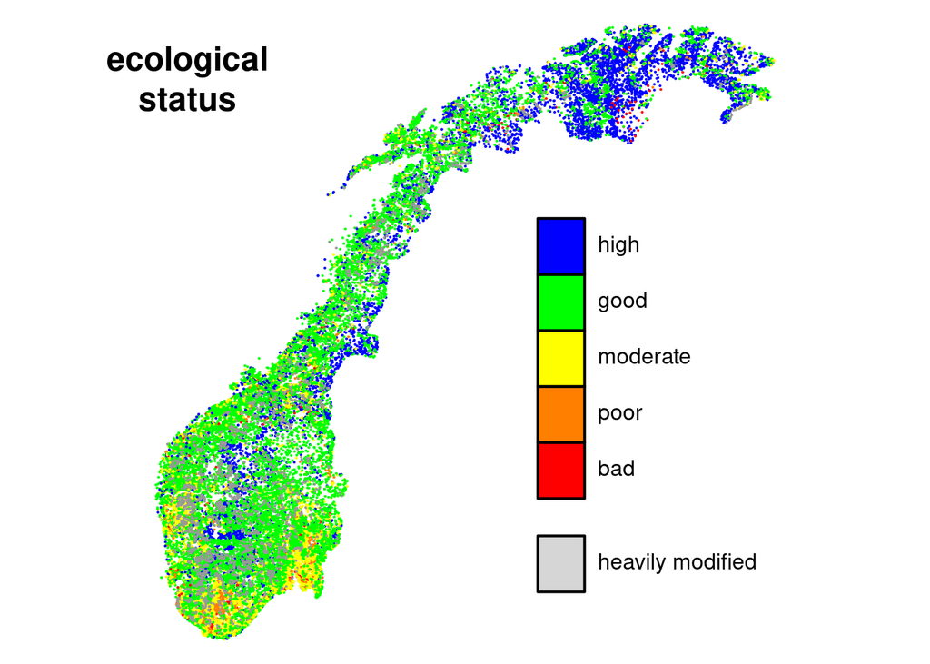

Figure 1: Map of all river and lake water bodies in Norway, using WFD colour coding for ecological status classes.

```r
par(mai = rep(0, 4))
plot(V$lon, V$lat, bty = "n", xaxt = "n", yaxt = "n", asp = 2,
     pch = 20, col = V$farge, cex = 0.2)
for (i in seq(0.1, 0.9, 0.2)) {
  rect(21, 61 + (i - 0.1) * 6, 23, 61 + (i + 0.1) * 6, col = farge(i), lwd = 2)
}
rect(21, 59, 23, 60.2, col = grey(0.84), lwd = 2)
text(23, 59 + 0.1 * 6, "heavily modified", pos = 4)
text(23, 61 + 0.1 * 6, "bad", pos = 4)
text(23, 61 + 0.3 * 6, "poor", pos = 4)
text(23, 61 + 0.5 * 6, "moderate", pos = 4)
text(23, 61 + 0.7 * 6, "good", pos = 4)
text(23, 61 + 0.9 * 6, "high", pos = 4)
text(6, 70, "ecological\nstatus", cex = 1.5, font = 2)
```

… and tabulated.

```r
{
  cat("Inspection of the dataset:\n")
  cat("--------------------------\n")

  cat("\nHeavily modified (TRUE) and natural (FALSE) water bodies:")
  print(table(V$smvf, useNA = "always"))

  cat("\nDistribution of ecological status categories:")
  print(table(V$okotil, useNA = "always"))

  cat("\nDistribution of ecological potential categories:")
  print(table(V$okopot, useNA = "always"))

  cat("\nDistribution of precision categories:")
  print(table(V$okopre, useNA = "always"))

  cat("\nDistribution of surface water categories:")
  print(table(V$kat, useNA = "always"))

  cat("\nDistribution of water body areas (in km²):\n")
  print(summary(V$areal[which(V$kat != "R")]))

  cat("\nDistribution of lengths of river water bodies (in km):\n")
  print(summary(V$areal[which(V$kat == "R")]))
}
```

```
Inspection of the dataset:
--------------------------

Heavily modified (TRUE) and natural (FALSE) water bodies:
FALSE  TRUE  <NA>
29380  3895     0

Distribution of ecological status categories:
           Dårlig               God Ikke klassifisert     Ikke relevant
             1341             14648                27              3895
          Moderat      Svært dårlig         Svært god              <NA>
             5799               643              6922                 0

Distribution of ecological potential categories:
           Dårlig              Godt Ikke klassifisert     Ikke relevant
              825              1486                22             29380
          Moderat      Svært dårlig              <NA>
             1282               280                 0

Distribution of precision categories:
              Høy Ingen informasjon               Lav           Middels
             5134             13436              8281              6424
             <NA>
                0

Distribution of surface water categories:
    C     L     R  <NA>
 2281  6821 24173     0

Distribution of water body areas (in km²):
    Min.  1st Qu.   Median     Mean  3rd Qu.     Max.
   0.001    0.341    0.809   11.462    2.396 6501.456

Distribution of lengths of river water bodies (in km):
    Min.  1st Qu.   Median     Mean  3rd Qu.     Max.
   0.009    2.725    7.837   24.116   23.133 1274.115
```

The inspection has not revealed any unexpected data. We can now transform the ecological status categories into a numerical variable by replacing each category by the midpoint of its nEQR range.

```r
nsim <- 1000
# The values tabulated in the "Results" section were obtained using nsim = 10000

{
  nEQR <- matrix(status2nEQR(V$okotil), nrow(V), nsim)
  cat("Distribution of nEQR values among natural water bodies:\n")
  print(table(nEQR[which(!V$smvf), 1], useNA = "always"))
}
```

```
Distribution of nEQR values among natural water bodies:

  0.1   0.3   0.5   0.7   0.9  <NA>
  643  1341  5799 14648  6922    27
```

For *heavily modified water bodies* (see above), the relevant measure is their *ecological potential* rather than ecological status. Unfortunately, there is no established conversion from ecological potential to nEQR values. As a defining property of heavily modified water bodies is that they cannot reach “good” ecological status, however, it makes sense to define the upper boundary of ecological potential as 0.6 (which is the lower boundary of good ecological status), and to evenly distribute the four categories for ecological potential along the range between 0.0 and 0.6.

```r
{
  w <- which(V$smvf)
  nEQR[w, ] <- potential2nEQR(V$okopot[w])
  cat("Approximated nEQR values among heavily modified water bodies:\n")
  print(table(nEQR[which(V$smvf), 1], useNA = "always"))
}
```

```
Approximated nEQR values among heavily modified water bodies:

0.075 0.225 0.375 0.525  <NA>
  280   825  1282  1486    22
```

Randomisation is used in order to quantify uncertainties. For each water body, *Vann-nett* provides the precision of its classification (i.e. its assignment to an ecological status or potential category). These are handled as follows:

1. “High precision” entails that the category is assigned based on an sufficient amount of actual measurements, and that their standard deviation is not close to a reference level. In these cases, the category as such can be regarded as certain, and uncertainty is restricted to the exact nEQR value within the interval defined by the category. The following randomisation draws random numbers from a uniform distribution that covers the entire interval.
2. “Intermediate precision” entails a certain likelihood that the ecological status or potential has been misassigned. In the randomisation below, 75% of random numbers are drawn from a uniform distribution from the relevant interval, while 12.5% are up to 0.067 nEQR units less than the lower boundary of the interval (i.e. within the upper third of the lower status or potential category), and 12.5% are up to 0.067 nEQR units greater than the upper boundary of the interval (i.e. within the lower third of the higher status or potential category). The latter random numbers are drawn from beta(1,2) distributions (i.e. triangular), assuming decreasing probability with increasing distance from the boundary.
3. “Low precision” entails a considerable likelihood that the ecological status or potential has been misassigned. In the randomisation below, 50% of random numbers are drawn from a uniform distribution from the relevant interval, while 25% are up to 0.2 nEQR units (or one status/potential category) less than the lower boundary of the interval, and 25% are up to 0.2 nEQR units (or one status/potential category) greater than the upper boundary of the interval. The latter random numbers are drawn from beta(1,2) distributions (i.e. triangular), assuming decreasing probability with increasing distance from the boundary. Water bodies with “no information”, which are assigned to an ecological status or potential category based on expert judgement, are treated in the same way.

```r
set.seed(144)

w <- which(!V$smvf & V$okopre == "Høy")
nEQR[w, ] <-          lowUncertainty(nEQR[w, ], FALSE)
w <- which(!V$smvf & V$okopre == "Middels")
nEQR[w, ] <- intermediateUncertainty(nEQR[w, ], FALSE)
w <- which(!V$smvf & V$okopre != "Høy" & V$okopre != "Middels")
nEQR[w, ] <-         highUncertainty(nEQR[w, ], FALSE)
w <- which( V$smvf & V$okopre == "Høy")
nEQR[w, ] <-          lowUncertainty(nEQR[w, ], TRUE)
w <- which( V$smvf & V$okopre == "Middels")
nEQR[w, ] <- intermediateUncertainty(nEQR[w, ], TRUE)
w <- which( V$smvf & V$okopre != "Høy" & V$okopre != "Middels")
nEQR[w, ] <-         highUncertainty(nEQR[w, ], TRUE)
```

A few water bodies have “not been classified” (i.e. have not been assigned to any status or potential category). To these, nEQR values are assigned at random based on the distribution of nEQR among classified water bodies, separately for natural and heavily modified water bodies of each surface water category.

```r
for (vannkategori in c("R", "L", "C")) {
  w1 <- which(!V$smvf &  is.na(nEQR[, 1]) & V$kat == vannkategori)
  w2 <- which(!V$smvf & !is.na(nEQR[, 1]) & V$kat == vannkategori)
  if (length(w1)) nEQR[w1, ] <- sample(nEQR[w2, ], length(w1) * nsim)
  w1 <- which( V$smvf &  is.na(nEQR[, 1]) & V$kat == vannkategori)
  w2 <- which( V$smvf & !is.na(nEQR[, 1]) & V$kat == vannkategori)
  if (length(w1)) nEQR[w1, ] <- sample(nEQR[w2, ], length(w1) * nsim)
}

if (any(is.na(nEQR))) {
  cat("NB: Some water bodies have still not been assigned an nEQR value!\n")
} else {
  cat("Everything is fine - all water bodies have an nEQR value.\n")
}
```

```
Everything is fine - all water bodies have an nEQR value.
```

### 9.2. Indicator definition A

Indicator definition **A** is the *unweighted proportion of water bodies with at least good ecological status*.

This is the definition that is most in line with Eurostat’s wording, which is: “Percentage of lakes and reservoirs / rivers and canals with good ecological status”, assuming that the addition of “*at least*” was intended by Eurostat (otherwise, water bodies with *high* ecological status would *reduce* the indicator value). All four inconsistencies with SEEA EA apply to this definition, however.

According to this definition, heavily modified water bodies are treated as having poorer than good ecological status, irrespective of their ecological potential. This is in accordance with the definition of heavily modified water bodies (see above).

```r
for (vannkategori in c("R", "L", "C")) {
  cat("Surface water category " %+% vannkategori %+% ":\n")
  nEQR. <- nEQR[which(V$kat == vannkategori), ]
  nEQR.[ V$smvf[which(V$kat == vannkategori)],] <- 0
  nEQR.[] <- as.numeric(nEQR.[] > 0.6)
  print(quantile(apply(nEQR., 2, mean), Qnt))
  cat("\n\n")
}
```

```
Surface water category R:
     2.5%       25%       50%       75%     97.5%
0.5684855 0.5706780 0.5719191 0.5731188 0.5757250


Surface water category L:
     2.5%       25%       50%       75%     97.5%
0.5870070 0.5915555 0.5937546 0.5961003 0.6003519


Surface water category C:
     2.5%       25%       50%       75%     97.5%
0.6115739 0.6207804 0.6245068 0.6291100 0.6374397
```

### 9.3. Indicator definition B

Indicator definition **B** is the *unweighted proportion of water bodies with at least good ecological status or good ecological potential*.

According to this definition, heavily modified water bodies with good ecological *potential* are treated as if they had good ecological *status*, as is current practice in, e.g., England (Environment Agency & Natural England 2025). The four inconsistencies with SEEA EA apply to this definition as well.

```r
nEQR. <- nEQR
w1 <- which(!V$smvf)
w2 <- which( V$smvf)
nEQR.[w1, ] <- as.numeric(nEQR.[w1, ] > 0.60)
nEQR.[w2, ] <- as.numeric(nEQR.[w2, ] > 0.45)
for (vannkategori in c("R", "L", "C")) {
  cat("Surface water category " %+% vannkategori %+% ":\n")
  w <- which(V$kat == vannkategori)
  print(quantile(apply(nEQR.[w, ], 2, mean), Qnt))
  cat("\n\n")
}
```

```
Surface water category R:
     2.5%       25%       50%       75%     97.5%
0.6014148 0.6038555 0.6050966 0.6064721 0.6089852


Surface water category L:
     2.5%       25%       50%       75%     97.5%
0.6718956 0.6773200 0.6799590 0.6824513 0.6869997


Surface water category C:
     2.5%       25%       50%       75%     97.5%
0.6190158 0.6282332 0.6321789 0.6365629 0.6453310
```

### 9.4. Indicator definition C

Indicator definition **C** is the *size-weighted proportion of water bodies with at least good ecological status*.

```r
for (vannkategori in c("R", "L", "C")) {
  cat("Surface water category " %+% vannkategori %+% ":\n")
  w <- which(V$kat == vannkategori)
  nEQR. <- nEQR[w, ]
  nEQR.[ V$smvf[w],] <- 0
  nEQR.[] <- as.numeric(nEQR.[] > 0.6)
  print(quantile(apply(nEQR., 2, weighted.mean, w = V$areal[w]), Qnt))
  cat("\n\n")
}
```

```
Surface water category R:
     2.5%       25%       50%       75%     97.5%
0.6897895 0.6943926 0.6968619 0.6994592 0.7047435


Surface water category L:
     2.5%       25%       50%       75%     97.5%
0.4512655 0.4576205 0.4605557 0.4632256 0.4688932


Surface water category C:
     2.5%       25%       50%       75%     97.5%
0.7252374 0.7889021 0.8085377 0.8220320 0.8410092
```

### 9.5. Indicator definition D

Indicator definition **D** is the *size-weighted average of ecological status or ecological potential*.

This definition deviates even more from Eurostat’s suggestion, and it violates SEEA EA in terms of issues 1 and 2.

Ideally, the ecological status of a water bodies should be provided in terms of continuous nEQR scores. However, in the *Vann-nett* database, ecological status is only available in terms of categories, which therefore need to be converted into numbers. The uncertainty inherent in this step is quantified by using random numbers (see above) and reported, as for the other definitions, in terms of quantiles. (As long as ecological status is *not* reported in terms of nEQR values, possible values of the indicator are actually between 0.1 and 0.9, rather than between 0.0 and 1.0. It would be straightforward to correct for this inconvenience numerically, viz. `i* = (i - 0.1) * 1.25`. This would entail that the “corrected” indicator `i*` is not interpretable as an nEQR any more, however, which is why this correction has not been applied here.)

```r
for (vannkategori in c("R", "L", "C")) {
  cat("Surface water category " %+% vannkategori %+% ":\n")
  w <- which(V$kat == vannkategori)
  nEQR. <- nEQR[w, ]
  print(quantile(apply(nEQR., 2, weighted.mean, w = V$areal[w]), Qnt))
  cat("\n\n")
}
```

```
Surface water category R:
     2.5%       25%       50%       75%     97.5%
0.6924808 0.6944952 0.6955619 0.6966135 0.6985808


Surface water category L:
     2.5%       25%       50%       75%     97.5%
0.5990057 0.6032756 0.6054262 0.6075015 0.6117684


Surface water category C:
     2.5%       25%       50%       75%     97.5%
0.6925206 0.7021525 0.7086590 0.7141146 0.7245773
```

### 9.6. Comparison

As expected, indicator values estimated in accordance with definition **B** are higher than ones estimated with definition **A**. This is because **A** considers all heavily modified water bodies to be in less than “good” status, wheres **B** equates “good potential” with “good status”, so that the fraction increases by an amount corresponding to water bodies in the latter condition. Both approaches are defendable: **A** is obviously in better accordance with the definition of “heavily modified water bodies” (see above), precisely because this definition implies that “good status” is unachievable for them. For water management, however, it is reasonable to concentrate on the “second-best goal” available for such water bodies, which is ensuring “good potential”. Counting water bodies with “good potential” as a management success, as definition **B** does, therefore makes some sense. Such considerations should not normally be allowed to influence an ecosystem condition account, however, so that **B** is even less in line with SEEA EA than **A**.

The difference between definitions **A** and **C** is that **A** ignores the size of the water bodies. As can be seen from the results, this may lead to deviations in both directions. In the case of lakes, smaller water bodies have a better ecological status, on average, than larger water bodies. Therefore, the area-weighted indicator (**C**) is lower than the unweighted one (**A**). For river and coastal water bodies, the reverse seems to be the case, since the size-weighted indicator values are higher than the unweighted ones. (It should be mentioned that the area of a lake water body is an ecologically relevant characteristic of the lake, whereas the length of river water bodies and area of coastal water are not, since the delineation of these water bodies is arbitrary.) Area-weighted indicators are clearly more in line with SEEA EA (see above).

Finally, the difference between definitions **C** and **D** is that **C** ignores the precise value of the underlying variable by purely counting the proportion of water bodies reaching a certain threshold (see above). This can also lead to deviations in both directions. For lakes, the *average* ecological status is barely “good” (an approximated mean nEQR of 0.61) – although less than half of the area covered by lakes (46%) is actually in “good status”. For coastal water bodies, on the other hand, the area in “good status” (81%) gives a higher indicator value than the average ecological status (0.71). In the case of rivers, both figures are surprisingly similar (close to 0.7).

Of all definitions considered, **D** is closest to the SEEA EA framework. However, even this definition has two incompatibilites with SEEA EA (which it shares with definitions **A**–**C**). For this reason, we cannot recommend any of the definitions tested. Instead of an indicator based on the overall ecological status of water bodies, an ecosystem condition account should rely on the primary indicators underlying the estimate of overall status. *If* a single value capturing the ecological status of surface water ecosystems is desirable, it should rather be based on an index calculated from these indicators (as outlined in section 3.3 above).

## 10. Results

The results are here tabulated separately for the three surface water categories (which correspond to ecosystem types sensu SEEA EA) and four indicator definitions. *Note that we cannot recommend any of the definitions*.

The estimates are based on 10,000 iterations and therefore differ from the ones above, which were based on 1,000 iterations only. *Note also that estimates are for August 2025 rather than for 2024* (see above).

### 10.1. Rivers

Table 4: Indicator values for different definitions of ecological status of rivers in Norway in 2025

| Indicator ID | Definition | Best estimate | Lower quartile | Upper quartile |
| --- | --- | --- | --- | --- |
| NO_WECO_001 | Def. A | 0.572 | 0.571 | 0.573 |
| NO_WECO_004 | Def. B | 0.605 | 0.604 | 0.606 |
| NO_WECO_007 | Def. C | 0.697 | 0.694 | 0.700 |
| NO_WECO_010 | Def. D | 0.696 | 0.694 | 0.697 |

### 10.2. Lakes

Table 5: Indicator values for different definitions of ecological status of lakes in Norway in 2025

| Indicator ID | Definition | Best estimate | Lower quartile | Upper quartile |
| --- | --- | --- | --- | --- |
| NO_WECO_002 | Def. A | 0.594 | 0.591 | 0.596 |
| NO_WECO_005 | Def. B | 0.680 | 0.677 | 0.683 |
| NO_WECO_008 | Def. C | 0.461 | 0.457 | 0.463 |
| NO_WECO_011 | Def. D | 0.605 | 0.603 | 0.608 |

### 10.3. Coastal waters

Table 6: Indicator values for different definitions of ecological status of coastal waters in Norway in 2025

| Indicator ID | Definition | Best estimate | Lower quartile | Upper quartile |
| --- | --- | --- | --- | --- |
| NO_WECO_003 | Def. A | 0.625 | 0.620 | 0.629 |
| NO_WECO_006 | Def. B | 0.632 | 0.628 | 0.637 |
| NO_WECO_009 | Def. C | 0.808 | 0.791 | 0.822 |
| NO_WECO_012 | Def. D | 0.709 | 0.703 | 0.714 |